# Homework 6

Nick Matthews; nickmatthews713

4/22/2020

## Top dogs

In this homework, you will try to reproduce the fantastic infographic for [top dogs](https://informationisbeautiful.net/visualizations/best-in-show-whats-the-top-data-dog/), originally produced by David McCandless. The raw data can be found [here](https://docs.google.com/spreadsheets/d/1l_HfF5EaN-QgnLc2UYdCc7L2CVrk0p3VdGB1godOyhk/edit#gid=10). You can download this file by File – Download As – Microsoft Excel (.xlsx).

1. Import the data and clean appropriately. To read in the data, you can use `readxl::read_xlsx('fileNameHere', sheet='sheetNameHere')`. Required data are in the sheets `Best in show` and `Best in show full sheet`. Take extra care on the column names and the first few rows of the data frame after read in.

```r
# Libraries
library(tidyr)
library(tidyverse)
library(dplyr)
library(naniar)
# Loading Data
bis <- readxl::read_xlsx('KIB - Best in Show (public).xlsx', sheet='Best in show',range ="A6:AX179")
bis <- bis[-1,]
# Cleaning Data: Get rid of columns I don't think are useful
bis <- bis %>%
  select(-starts_with(".")) %>%
  select(-c("congenital ailments: summary / areas affected", "exclude?", "congenital ailments: detail",
            "lowest (US$)","highest (US$)","food per week, average, £","min, £","max, £","food per week, $",
            "total per lifetime, $","total, per year, £","toys, presents, treats, per year, £",
            "pet sitters, per year, £","grooming, per year, £","vet fees per year, £","kennels per year, £",
            "one offs, $","total  per year, $"))

# Rename columns / replace "no data" and "-" with NA / convert types
bis <- bis %>%
  rename(breed="Dog breed",popularity="popularity ranking (1-173, 1 = most popular)",
         intelligence="intelligence ranking",intelligence_category="intelligence category",
         rep_to_learn="repetitions to understand new commands",
         obey_command_percentage="obey first command (% of time)",life_expectancy="life expectancy (years)",
         survey_sample_size="survey sample size",number_congenital_aliments="No.",
         cuteness_rating="cuteness rating (adults)",lifetime_cost="total lifetime cost, $",
         average_buy_price="average price (US $)",price_bracket="price bracket",
         lifetime_food_cost="food per lifetime, $", grooming_required="grooming required",
         size="size category") %>%
  replace_with_na_all(condition = ~.x == "no data") %>%
  replace_with_na_all(condition = ~.x == "-") %>%
  type.convert()
```

2. Create a graphics similar to the [top dogs](https://informationisbeautiful.net/visualizations/best-in-show-whats-the-top-data-dog/) figure. Your figure needs to display the following information with appropriate plotting elements:

```r
# We need to do a bit more work in order to trim down the number of variables in order to replicate
# the six simple data score variables (intelligence, costs, longevity, grooming, ailments, and appetite)
bisSimple <- bis %>%
  separate(rep_to_learn, into = c("learn_rep_low", "learn_rep_high"), sep = "-") %>%
  mutate(avg_learn_rep = (as.numeric(learn_rep_low) + as.numeric(learn_rep_high))/2) %>%
  select(-c("learn_rep_low","learn_rep_high")) %>%
  select(breed, category, popularity, intelligence, lifetime_cost, lifetime_food_cost, life_expectancy,
         avg_learn_rep, number_congenital_aliments, size)
bisSimple$life_expectancy <- as.numeric(bisSimple$life_expectancy)
```

```r
library(scales)
# Select only the columns needed for my data score, popularity, size, and inteligence. Then
# scale each of the numeric columns so that they may be combined for a score. I use the
# "scales" package to scale the columns in between 0 and 1
bisSimple$popularity <- rescale(bisSimple$popularity)
bisSimple$intelligence <- rescale(bisSimple$intelligence)
bisSimple$lifetime_cost <- rescale(bisSimple$lifetime_cost)
bisSimple$lifetime_food_cost <- rescale(bisSimple$lifetime_food_cost)
bisSimple$life_expectancy <- rescale(bisSimple$life_expectancy)
bisSimple$number_congenital_aliments <- rescale(bisSimple$number_congenital_aliments)
```

```r
# Here I create the data_score by taking an average of all the data_score scaled columns
bisSimple <- bisSimple %>%
  rowwise() %>%
  mutate(data_score = sum(intelligence,lifetime_cost,lifetime_food_cost,
                          number_congenital_aliments, na.rm = TRUE)/4) %>%
  filter(data_score > 0) %>%
  mutate(data_score = data_score*-1) %>%
  mutate(popularity = popularity*-1) %>%
  mutate(intelligent = ifelse(avg_learn_rep > 21,"Smart","Dumb"), na.rm=TRUE)

bisSimple$size <- as.numeric(bisSimple$size)

bisSimple$size[bisSimple$size == 1] <- 1.75
bisSimple$size[bisSimple$size == 2] <- 2.5
bisSimple$size[bisSimple$size == 3] <- 3.5
```

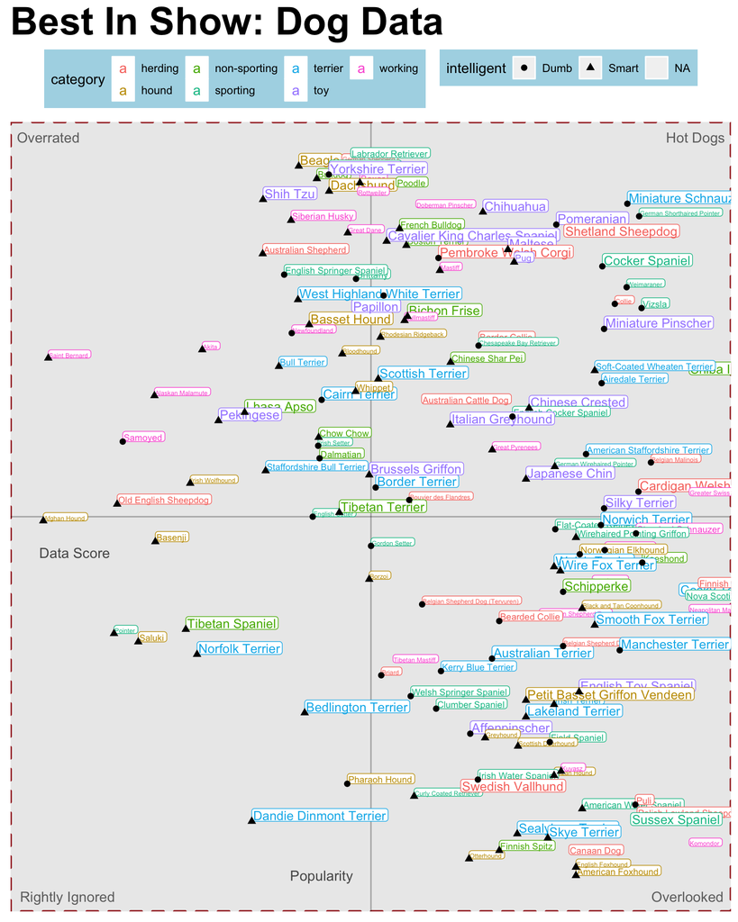

```r
annotations <- data.frame(
        xpos = c(-Inf,-Inf,Inf,Inf),
        ypos =  c(-Inf, Inf,-Inf,Inf),
        annotateText = c("Rightly Ignored","Overrated"
                        ,"Overlooked","Hot Dogs"),
        hjustvar = c(-0.1,-0.1,1.1,1.1),
        vjustvar = c(-1,2,-1,2))

x_axis_label <- tibble(x=-0.4,y=-1,text="Popularity")
y_axis_label <- tibble(x=-0.65,y=-0.55,text="Data Score")

bisSimple %>%
  ggplot(aes(x=data_score,y=popularity, label=breed)) +
  geom_hline(yintercept = -0.5, alpha=0.3) +
  geom_vline(xintercept = -0.35, alpha=0.3) +
  geom_label(aes(color=category),label.padding = unit(0.1,"lines"),hjust=0,vjust=0,
             size=bisSimple$size,check_overlap = TRUE) +
  geom_point(aes(shape=intelligent),size=2) +
  scale_size(range = c(1.75,3)) +
  geom_text(data=annotations,aes(x=xpos,y=ypos,hjust=hjustvar,vjust=vjustvar,label=annotateText),alpha=0.6) +
  geom_text(data=x_axis_label,aes(x=x,y=y,label=text),alpha=0.7) +
  geom_text(data=y_axis_label,aes(x=x,y=y,label=text),alpha=0.7) +
  ggtitle("Best In Show: Dog Data") +
  theme(axis.title.x=element_blank(),
        axis.text.x=element_blank(),
        axis.ticks.x=element_blank(),
        axis.title.y=element_blank(),
        axis.text.y=element_blank(),
        axis.ticks.y=element_blank(),
        panel.grid.major = element_blank(),
        panel.grid.minor = element_blank(),
        legend.position = "top",
        legend.background = element_rect(fill="lightblue"),
        panel.background = element_rect(color = "brown", size = 1,linetype = "dashed"),
        plot.title = element_text(size = 30,face = "bold"))
```

## Description:

This is my final result. After many many attempts I could not get to making a legend for the size of the dog. However, I was able to show it through the size of each geom_label(). Overall, here’s what I was able to show…  
1) The Breed through **geom_label()**  
2) The type(category) through a color scheme, which contrasts pretty well  
3) The 3 sizes of the dog (large, medium, and small) but without a legend :(  
4) The popularity and data score by scaling variables  
5) The intelligence through shape of geom_point  
6) Get minimal overlap by using hjust and vjust, and also making the plot BIGGER!!  
Getting the dogs to be positioned similar to that of the actual graph we had to replicate was hard. obviously he used a very specific scale to decide the data_score(much different from mine). But I guess that is somewhat subjective.